# Used Car Price Prediciton

In this project, I will use the Audi car dataset to predict the price of a used car. I will be performing some EDA and use regression models to predict the car price.

## Objective

The main objective of this project is to predict the price of a used Audi car based on its different features such as model, year, transmission, mileage, fuel type, tax, mpg and engine size.

## Importing the required libraries

```python
import numpy as np
import pandas as pd
import matplotlib.pyplot as plt
```

## loading the Dataset

The dataset used for this project is audi.csv.

```python
df = pd.read_csv("audi.csv")
```

```python
display(df)
```

|  | model | year | price | transmission | mileage | fuelType | tax | mpg | engineSize |
| --- | --- | --- | --- | --- | --- | --- | --- | --- | --- |
| 0 | A1 | 2017 | 12500 | Manual | 15735 | Petrol | 150 | 55.4 | 1.4 |
| 1 | A6 | 2016 | 16500 | Automatic | 36203 | Diesel | 20 | 64.2 | 2.0 |
| 2 | A1 | 2016 | 11000 | Manual | 29946 | Petrol | 30 | 55.4 | 1.4 |
| 3 | A4 | 2017 | 16800 | Automatic | 25952 | Diesel | 145 | 67.3 | 2.0 |
| 4 | A3 | 2019 | 17300 | Manual | 1998 | Petrol | 145 | 49.6 | 1.0 |
| ... | ... | ... | ... | ... | ... | ... | ... | ... | ... |
| 10663 | A3 | 2020 | 16999 | Manual | 4018 | Petrol | 145 | 49.6 | 1.0 |
| 10664 | A3 | 2020 | 16999 | Manual | 1978 | Petrol | 150 | 49.6 | 1.0 |
| 10665 | A3 | 2020 | 17199 | Manual | 609 | Petrol | 150 | 49.6 | 1.0 |
| 10666 | Q3 | 2017 | 19499 | Automatic | 8646 | Petrol | 150 | 47.9 | 1.4 |
| 10667 | Q3 | 2016 | 15999 | Manual | 11855 | Petrol | 150 | 47.9 | 1.4 |

10668 rows × 9 columns

## Understanding the dataset

Before building a model, I will check the size and struture of the dataset.

```python
print("Number of Records:",len(df))
print("Shape of Dataset:",df.shape)
```

```
Number of Records: 10668
Shape of Dataset: (10668, 9)
```

```python
display(df.head())
```

|  | model | year | price | transmission | mileage | fuelType | tax | mpg | engineSize |
| --- | --- | --- | --- | --- | --- | --- | --- | --- | --- |
| 0 | A1 | 2017 | 12500 | Manual | 15735 | Petrol | 150 | 55.4 | 1.4 |
| 1 | A6 | 2016 | 16500 | Automatic | 36203 | Diesel | 20 | 64.2 | 2.0 |
| 2 | A1 | 2016 | 11000 | Manual | 29946 | Petrol | 30 | 55.4 | 1.4 |
| 3 | A4 | 2017 | 16800 | Automatic | 25952 | Diesel | 145 | 67.3 | 2.0 |
| 4 | A3 | 2019 | 17300 | Manual | 1998 | Petrol | 145 | 49.6 | 1.0 |

## Checking the columns and data types

Now I will check the column names and the data type of each column.

```python
display(df.dtypes)
```

```
model            object
year              int64
price             int64
transmission     object
mileage           int64
fuelType         object
tax               int64
mpg             float64
engineSize      float64
dtype: object
```

## Checking for missing values

I will check whether any column contains missing values before doing further analysis.

```python
display(df.isna().sum())
```

```
model           0
year            0
price           0
transmission    0
mileage         0
fuelType        0
tax             0
mpg             0
engineSize      0
dtype: int64
```

## Dataset information

I will use info() to get a quick summary of the dataset, including the number of non-null values and data types.

```python
df.info()
```

```
<class 'pandas.core.frame.DataFrame'>
RangeIndex: 10668 entries, 0 to 10667
Data columns (total 9 columns):
 #   Column        Non-Null Count  Dtype
---  ------        --------------  -----
 0   model         10668 non-null  object
 1   year          10668 non-null  int64
 2   price         10668 non-null  int64
 3   transmission  10668 non-null  object
 4   mileage       10668 non-null  int64
 5   fuelType      10668 non-null  object
 6   tax           10668 non-null  int64
 7   mpg           10668 non-null  float64
 8   engineSize    10668 non-null  float64
dtypes: float64(2), int64(4), object(3)
memory usage: 750.2+ KB
```

## Checking duplicate records

Duplicate records can affect the analysis, so I will check how many duplicate rows are present.

```python
print("Number of duplicate rows:",df.duplicated().sum())
```

```
Number of duplicate rows: 103
```

## Statistical summary

Now I will look at some basic statistics of the numerical columns.

```python
display(df.describe())
```

|  | year | price | mileage | tax | mpg | engineSize |
| --- | --- | --- | --- | --- | --- | --- |
| count | 10668.000000 | 10668.000000 | 10668.000000 | 10668.000000 | 10668.000000 | 10668.000000 |
| mean | 2017.100675 | 22896.685039 | 24827.244001 | 126.011436 | 50.770022 | 1.930709 |
| std | 2.167494 | 11714.841888 | 23505.257205 | 67.170294 | 12.949782 | 0.602957 |
| min | 1997.000000 | 1490.000000 | 1.000000 | 0.000000 | 18.900000 | 0.000000 |
| 25% | 2016.000000 | 15130.750000 | 5968.750000 | 125.000000 | 40.900000 | 1.500000 |
| 50% | 2017.000000 | 20200.000000 | 19000.000000 | 145.000000 | 49.600000 | 2.000000 |
| 75% | 2019.000000 | 27990.000000 | 36464.500000 | 145.000000 | 58.900000 | 2.000000 |
| max | 2020.000000 | 145000.000000 | 323000.000000 | 580.000000 | 188.300000 | 6.300000 |

## Exploratory Data Analysis

Now I will explore the dataset using some graphs to understand the car prices and their relationship with different features.

### Distribution of Car Prices

First, I will look at the distribution of the car prices in the dataset.

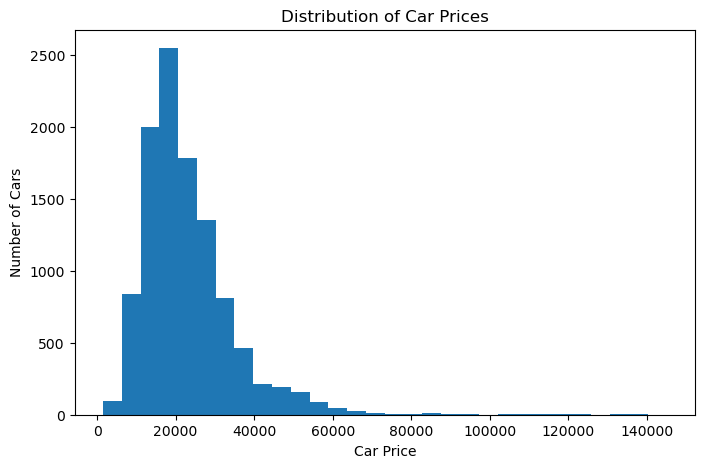

```python
plt.figure(figsize=(8,5))
plt.hist(df["price"], bins=30)
plt.xlabel("Car Price")
plt.ylabel("Number of Cars")
plt.title("Distribution of Car Prices")
plt.show()
```

### Price vs Year

Next, I will check whether the year of the car has any visible relationship with its price.

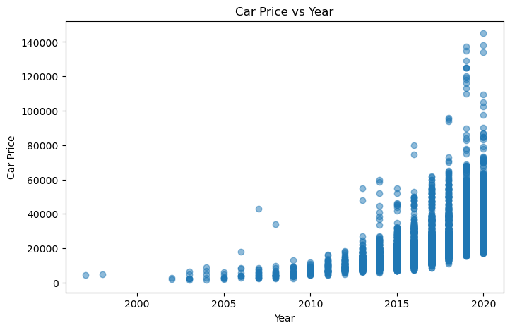

```python
plt.figure(figsize=(8,5))
plt.scatter(df["year"], df["price"], alpha=0.5)
plt.xlabel("Year")
plt.ylabel("Car Price")
plt.title("Car Price vs Year")
plt.show()
```

### Price vs Mileage

Checking the relationship between mileage and car price.

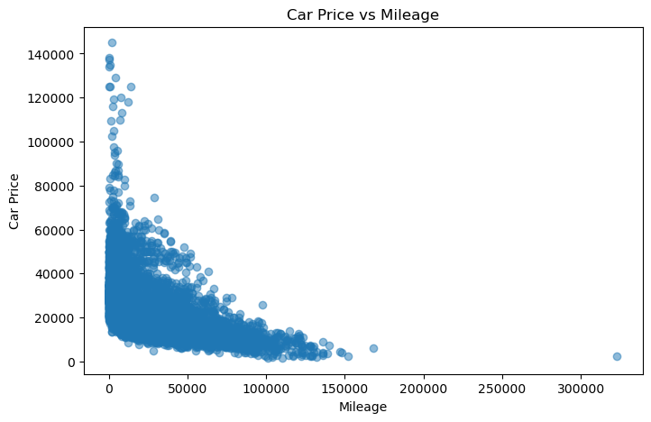

```python
plt.figure(figsize=(8,5))
plt.scatter(df["mileage"], df["price"], alpha=0.5)
plt.xlabel("Mileage")
plt.ylabel("Car Price")
plt.title("Car Price vs Mileage")
plt.show()
```

### Price by Fuel type

Comaparing Car prices for the different fuel prices.

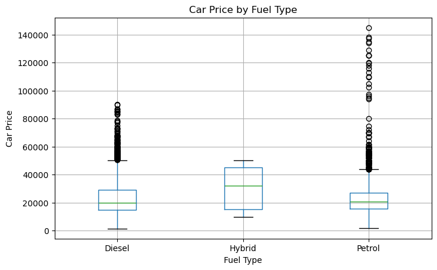

```python
df.boxplot(column="price", by="fuelType", figsize=(8,5))
plt.xlabel("Fuel Type")
plt.ylabel("Car Price")
plt.title("Car Price by Fuel Type")
plt.suptitle("")
plt.show()
```

### Price by Transmission

I will also compare the car prices for different transmission types.

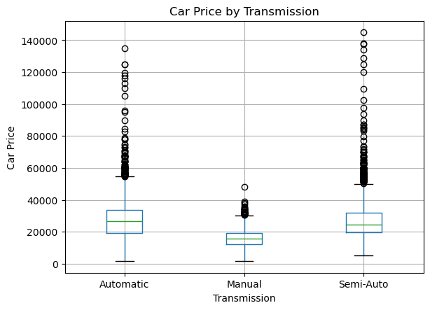

```python
plt.figure(figsize=(8,5))
df.boxplot(column="price", by="transmission")
plt.xlabel("Transmission")
plt.ylabel("Car Price")
plt.title("Car Price by Transmission")
plt.suptitle("")
plt.show()
```

### Price vs Engine Size

I will check whether engine size has a relationship with the price of the car.

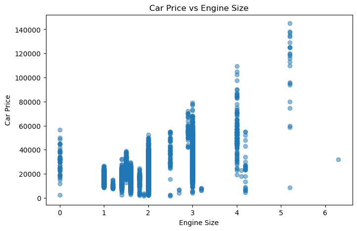

```python
plt.figure(figsize=(8,5))
plt.scatter(df["engineSize"], df["price"], alpha=0.5)
plt.xlabel("Engine Size")
plt.ylabel("Car Price")
plt.title("Car Price vs Engine Size")
plt.show()
```

### Average Price by Car Model

There are many different Audi models in the dataset, so I will compare their average prices.

```python
model_avg_price = df.groupby("model")["price"].mean().sort_values(ascending=False)

display(model_avg_price)
```

```
model
R8     97652.214286
Q8     60115.014493
RS6    55963.871795
RS5    51265.206897
RS4    50151.612903
SQ7    49269.000000
Q7     44788.319899
A8     34981.847458
RS3    34050.515152
S8     33807.750000
RS7    33490.000000
SQ5    31415.812500
S4     31248.083333
Q5     30445.688712
A7     28865.516393
A5     23577.114512
Q3     22999.261821
A6     22695.385027
Q2     22516.975669
TT     21784.452381
S3     20379.444444
A4     20255.450398
A3     17408.522032
S5     15980.000000
A1     14327.750557
A2      2490.000000
Name: price, dtype: float64
```

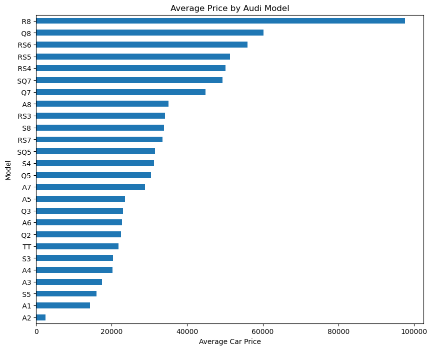

```python
plt.figure(figsize=(10,8))
model_avg_price.sort_values().plot(kind="barh")
plt.xlabel("Average Car Price")
plt.ylabel("Model")
plt.title("Average Price by Audi Model")
plt.show()
```

### Correlation between numerical features

I will check the correlation between the numerical columns to understand how they are related to each other and to car price.

```python
correlation = df.select_dtypes(include=np.number).corr()
display(correlation)
```

|  | year | price | mileage | tax | mpg | engineSize |
| --- | --- | --- | --- | --- | --- | --- |
| year | 1.000000 | 0.592581 | -0.789667 | 0.093066 | -0.351281 | -0.031582 |
| price | 0.592581 | 1.000000 | -0.535357 | 0.356157 | -0.600334 | 0.591262 |
| mileage | -0.789667 | -0.535357 | 1.000000 | -0.166547 | 0.395103 | 0.070710 |
| tax | 0.093066 | 0.356157 | -0.166547 | 1.000000 | -0.635909 | 0.393075 |
| mpg | -0.351281 | -0.600334 | 0.395103 | -0.635909 | 1.000000 | -0.365621 |
| engineSize | -0.031582 | 0.591262 | 0.070710 | 0.393075 | -0.365621 | 1.000000 |

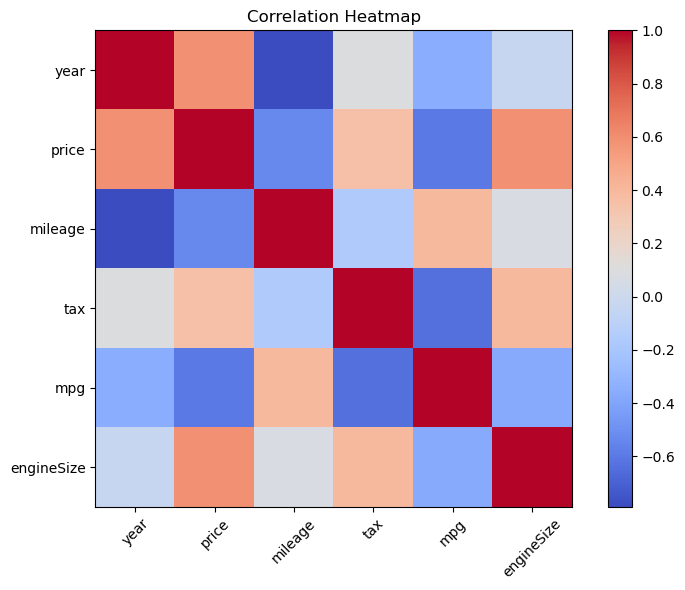

```python
plt.figure(figsize=(8,6))
plt.imshow(correlation, cmap="coolwarm", interpolation="nearest")
plt.colorbar()

plt.xticks(range(len(correlation.columns)), correlation.columns, rotation=45)
plt.yticks(range(len(correlation.columns)), correlation.columns)

plt.title("Correlation Heatmap")
plt.tight_layout()
plt.show()
```

## Data Cleaning

The initial EDA is now complete. Before preparing the data for machine learning, I will check the duplicate records and make sure the dataset is ready for preprocessing.

## Removing Duplicate Records

The dataset contains some duplicate rows. I will remove the duplicate records before building the machine learning models.

```python
df = df.drop_duplicates()
```

```python
print("Shape after removing duplicates:", df.shape)
```

```
Shape after removing duplicates: (10565, 9)
```

```python
print("Duplicate rows remaining:", df.duplicated().sum())
```

```
Duplicate rows remaining: 0
```

## Checking Missing Values Again

After cleaning the duplicate records, I will check the dataset again for missing values.

```python
display(df.isna().sum())
```

```
model           0
year            0
price           0
transmission    0
mileage         0
fuelType        0
tax             0
mpg             0
engineSize      0
dtype: int64
```

## Separating Features and Target

The target variable for this project is price.

The remaining columns will be used as features to predict the price.

```python
X = df.drop("price", axis=1)
y = df["price"]
```

```python
print("Features shape:", X.shape)
print("Target shape:", y.shape)
```

```
Features shape: (10565, 8)
Target shape: (10565,)
```

```python
display(X.head())
display(y.head())
```

|  | model | year | transmission | mileage | fuelType | tax | mpg | engineSize |
| --- | --- | --- | --- | --- | --- | --- | --- | --- |
| 0 | A1 | 2017 | Manual | 15735 | Petrol | 150 | 55.4 | 1.4 |
| 1 | A6 | 2016 | Automatic | 36203 | Diesel | 20 | 64.2 | 2.0 |
| 2 | A1 | 2016 | Manual | 29946 | Petrol | 30 | 55.4 | 1.4 |
| 3 | A4 | 2017 | Automatic | 25952 | Diesel | 145 | 67.3 | 2.0 |
| 4 | A3 | 2019 | Manual | 1998 | Petrol | 145 | 49.6 | 1.0 |

```
0    12500
1    16500
2    11000
3    16800
4    17300
Name: price, dtype: int64
```

## Splitting the Dataset

Before preprocessing the data and training the models, I will split the dataset into training and testing data.

The training data will be used to train the models, while the testing data will be used to evaluate their performance.

```python
from sklearn.model_selection import train_test_split

X_train, X_test, y_train, y_test = train_test_split(
    X,
    y,
    test_size=0.2,
    random_state=42
)
```

```python
print("X_train shape:", X_train.shape)
print("X_test shape:", X_test.shape)
print("y_train shape:", y_train.shape)
print("y_test shape:", y_test.shape)
```

```
X_train shape: (8452, 8)
X_test shape: (2113, 8)
y_train shape: (8452,)
y_test shape: (2113,)
```

## Identifying Categorical and Numerical Features

The dataset contains both numerical and categorical features.

The categorical columns will need to be encoded before they can be used by the machine learning models.

```python
categorical_features = X.select_dtypes(include=["object"]).columns.tolist()
numerical_features = X.select_dtypes(exclude=["object"]).columns.tolist()

print("Categorical features:", categorical_features)
print("Numerical features:", numerical_features)
```

```
Categorical features: ['model', 'transmission', 'fuelType']
Numerical features: ['year', 'mileage', 'tax', 'mpg', 'engineSize']
```

## Preprocessing

I will use OneHotEncoder for the categorical features.

This converts categories such as different car models, transmission types and fuel types into numerical columns that the machine learning models can use.

```python
from sklearn.preprocessing import OneHotEncoder
from sklearn.compose import ColumnTransformer

preprocessor = ColumnTransformer(
    transformers=[
        ("categorical", OneHotEncoder(handle_unknown="ignore"), categorical_features)
    ],
    remainder="passthrough"
)
```

## Fitting the Preprocessor on Training Data

The preprocessor will be fitted using only the training data.

After that, the same preprocessing will be applied to both the training and testing data.

```python
X_train_processed = preprocessor.fit_transform(X_train)
X_test_processed = preprocessor.transform(X_test)
```

```python
print("Processed X_train shape:", X_train_processed.shape)
print("Processed X_test shape:", X_test_processed.shape)
```

```
Processed X_train shape: (8452, 37)
Processed X_test shape: (2113, 37)
```

## Checking the Processed Features

The categorical columns have now been converted into numerical features. I will check the processed training data before using it for model training.

```python
print("Number of processed features:", X_train_processed.shape[1])
```

```
Number of processed features: 37
```

```python
display(pd.DataFrame(X_train_processed.toarray()).head())
```

|  | 0 | 1 | 2 | 3 | 4 | 5 | 6 | 7 | 8 | 9 | ... | 27 | 28 | 29 | 30 | 31 | 32 | 33 | 34 | 35 | 36 |
| --- | --- | --- | --- | --- | --- | --- | --- | --- | --- | --- | --- | --- | --- | --- | --- | --- | --- | --- | --- | --- | --- |
| 0 | 0.0 | 0.0 | 0.0 | 0.0 | 0.0 | 0.0 | 0.0 | 0.0 | 0.0 | 0.0 | ... | 0.0 | 0.0 | 1.0 | 0.0 | 0.0 | 2019.0 | 10.0 | 145.0 | 33.6 | 3.0 |
| 1 | 0.0 | 0.0 | 0.0 | 0.0 | 1.0 | 0.0 | 0.0 | 0.0 | 0.0 | 0.0 | ... | 0.0 | 0.0 | 1.0 | 0.0 | 0.0 | 2019.0 | 8065.0 | 145.0 | 50.4 | 2.0 |
| 2 | 0.0 | 0.0 | 1.0 | 0.0 | 0.0 | 0.0 | 0.0 | 0.0 | 0.0 | 0.0 | ... | 0.0 | 0.0 | 1.0 | 0.0 | 0.0 | 2019.0 | 2257.0 | 145.0 | 52.3 | 1.6 |
| 3 | 1.0 | 0.0 | 0.0 | 0.0 | 0.0 | 0.0 | 0.0 | 0.0 | 0.0 | 0.0 | ... | 1.0 | 0.0 | 0.0 | 0.0 | 1.0 | 2016.0 | 29819.0 | 0.0 | 67.3 | 1.0 |
| 4 | 0.0 | 0.0 | 0.0 | 1.0 | 0.0 | 0.0 | 0.0 | 0.0 | 0.0 | 0.0 | ... | 0.0 | 1.0 | 1.0 | 0.0 | 0.0 | 2014.0 | 28510.0 | 125.0 | 57.6 | 2.0 |

5 rows × 37 columns

## Linear Regression

I will first use Linear Regression as a basic regression model.

This will give us a baseline that we can compare with the other models later.

```python
from sklearn.linear_model import LinearRegression

linear_model = LinearRegression()
```

```python
linear_model.fit(X_train_processed, y_train)
```

```
LinearRegression()
```

### Making Predictions

After training the model, I will use it to predict the prices of the cars in the test dataset.

```python
y_pred_linear = linear_model.predict(X_test_processed)
```

```python
display(y_pred_linear[:10])
```

```
array([11490.36197289, 51777.2965324 , 22749.314999  , 17853.84420417,
       15293.78270619, 36302.65078534, 33818.77556098, 31865.22673014,
       11835.99401195, 13872.64934027])
```

## Evaluating the Linear Regression Model

I will use Mean Absolute Error (MAE) and R² score to evaluate the predictions.

```python
from sklearn.metrics import mean_absolute_error, r2_score

mae_linear = mean_absolute_error(y_test, y_pred_linear)
r2_linear = r2_score(y_test, y_pred_linear)

print("Linear Regression MAE:", mae_linear)
print("Linear Regression R² Score:", r2_linear)
```

```
Linear Regression MAE: 2716.3211589750113
Linear Regression R² Score: 0.8607129019700198
```

### Actual vs Predicted Prices

I will compare the actual car prices with the prices predicted by the Linear Regression model.

```python
comparison_linear = pd.DataFrame({
    "Actual Price": y_test.values,
    "Predicted Price": y_pred_linear
})

display(comparison_linear.head(10))
```

|  | Actual Price | Predicted Price |
| --- | --- | --- |
| 0 | 12691 | 11490.361973 |
| 1 | 47816 | 51777.296532 |
| 2 | 21450 | 22749.314999 |
| 3 | 13849 | 17853.844204 |
| 4 | 12990 | 15293.782706 |
| 5 | 45490 | 36302.650785 |
| 6 | 34985 | 33818.775561 |
| 7 | 23990 | 31865.226730 |
| 8 | 14998 | 11835.994012 |
| 9 | 12360 | 13872.649340 |

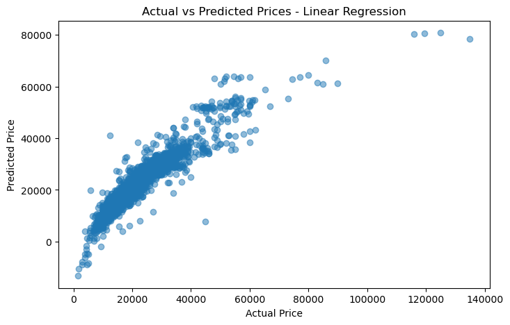

```python
plt.figure(figsize=(8,5))
plt.scatter(y_test, y_pred_linear, alpha=0.5)

plt.xlabel("Actual Price")
plt.ylabel("Predicted Price")
plt.title("Actual vs Predicted Prices - Linear Regression")

plt.show()
```

## Random Forest Regression

Training a Random Forest Regressor and comparing its performance with Linear Regression.

```python
from sklearn.ensemble import RandomForestRegressor

random_forest_model = RandomForestRegressor(random_state=42)
```

```python
random_forest_model.fit(X_train_processed, y_train)
```

```
RandomForestRegressor(random_state=42)
```

### Random Forest Predictions

I will now use the trained Random Forest model to predict prices for the test data.

```python
y_pred_rf = random_forest_model.predict(X_test_processed)

display(y_pred_rf[:10])
```

```
array([11585.43, 51032.23, 20666.87, 15114.05, 14252.31, 44342.76,
       31249.9 , 26046.21, 14135.33, 13141.22])
```

```python
mae_rf = mean_absolute_error(y_test, y_pred_rf)
r2_rf = r2_score(y_test, y_pred_rf)

print("Random Forest MAE:", mae_rf)
print("Random Forest R² Score:", r2_rf)
```

```
Random Forest MAE: 1563.3663434357486
Random Forest R² Score: 0.9566220818431
```

### Actual vs Predicted Prices - Random Forest

I will compare the actual prices with the prices predicted by the Random Forest model.

```python
comparison_rf = pd.DataFrame({
    "Actual Price": y_test.values,
    "Predicted Price": y_pred_rf
})

display(comparison_rf.head(10))
```

|  | Actual Price | Predicted Price |
| --- | --- | --- |
| 0 | 12691 | 11585.43 |
| 1 | 47816 | 51032.23 |
| 2 | 21450 | 20666.87 |
| 3 | 13849 | 15114.05 |
| 4 | 12990 | 14252.31 |
| 5 | 45490 | 44342.76 |
| 6 | 34985 | 31249.90 |
| 7 | 23990 | 26046.21 |
| 8 | 14998 | 14135.33 |
| 9 | 12360 | 13141.22 |

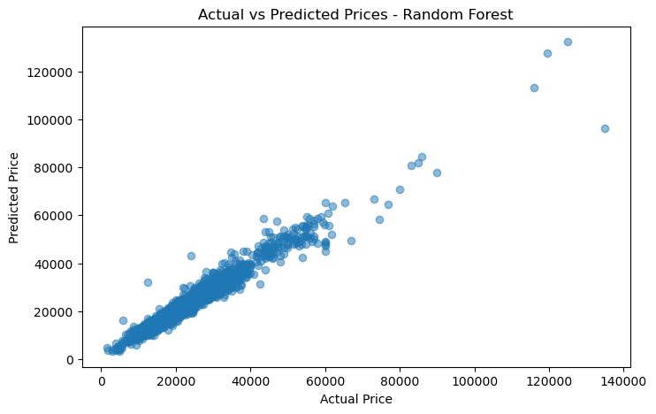

```python
plt.figure(figsize=(8,5))
plt.scatter(y_test, y_pred_rf, alpha=0.5)

plt.xlabel("Actual Price")
plt.ylabel("Predicted Price")
plt.title("Actual vs Predicted Prices - Random Forest")

plt.show()
```

## Extra Trees Regression

I will now train an Extra Trees Regressor and compare its performance with the previous models.

Extra Trees is another tree-based regression algorithm included in the reference project.

```python
from sklearn.ensemble import ExtraTreesRegressor

extra_trees_model = ExtraTreesRegressor(
    n_estimators=120,
    random_state=42
)
```

```python
extra_trees_model.fit(X_train_processed, y_train)
```

```
ExtraTreesRegressor(n_estimators=120, random_state=42)
```

### Extra Trees Predictions

I will use the trained Extra Trees model to predict the prices of the test data.

```python
y_pred_et = extra_trees_model.predict(X_test_processed)

display(y_pred_et[:10])
```

```
array([11400.        , 54059.        , 20585.275     , 14418.29166667,
       14160.28333333, 44342.45      , 30860.        , 27798.30833333,
       14058.80833333, 13175.25      ])
```

```python
mae_et = mean_absolute_error(y_test, y_pred_et)
r2_et = r2_score(y_test, y_pred_et)

print("Extra Trees MAE:", mae_et)
print("Extra Trees R² Score:", r2_et)
```

```
Extra Trees MAE: 1574.4888132986275
Extra Trees R² Score: 0.9581252504123355
```

### Actual vs Predicted Prices - Extra Trees

I will compare the actual prices with the prices predicted by the Extra Trees model.

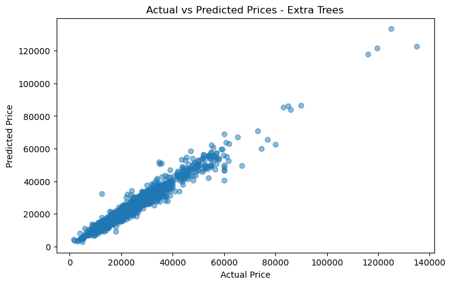

```python
plt.figure(figsize=(8,5))
plt.scatter(y_test, y_pred_et, alpha=0.5)

plt.xlabel("Actual Price")
plt.ylabel("Predicted Price")
plt.title("Actual vs Predicted Prices - Extra Trees")

plt.show()
```

```python
model_comparison = pd.DataFrame({
    "Model": [
        "Linear Regression",
        "Random Forest",
        "Extra Trees"
    ],
    "MAE": [
        mae_linear,
        mae_rf,
        mae_et
    ],
    "R2 Score": [
        r2_linear,
        r2_rf,
        r2_et
    ]
})

display(model_comparison)
```

|  | Model | MAE | R2 Score |
| --- | --- | --- | --- |
| 0 | Linear Regression | 2716.321159 | 0.860713 |
| 1 | Random Forest | 1563.366343 | 0.956622 |
| 2 | Extra Trees | 1574.488813 | 0.958125 |

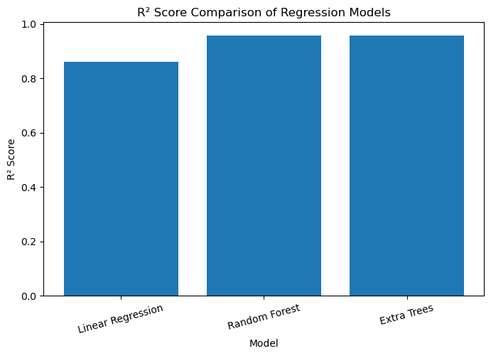

```python
plt.figure(figsize=(8,5))

plt.bar(model_comparison["Model"], model_comparison["R2 Score"])

plt.xlabel("Model")
plt.ylabel("R² Score")
plt.title("R² Score Comparison of Regression Models")

plt.xticks(rotation=15)
plt.show()
```

```python
best_model_name = model_comparison.loc[
    model_comparison["R2 Score"].idxmax(), "Model"
]

print("Best model based on R² Score:", best_model_name)
```

```
Best model based on R² Score: Extra Trees
```

## Feature Importance

Tree-based models can provide feature importance values.

I will use the Extra Trees model to see which processed features contributed most to the predictions.

```python
feature_names = preprocessor.get_feature_names_out()

feature_importance = pd.DataFrame({
    "Feature": feature_names,
    "Importance": extra_trees_model.feature_importances_
})

feature_importance = feature_importance.sort_values(
    "Importance",
    ascending=False
)

display(feature_importance.head(15))
```

|  | Feature | Importance |
| --- | --- | --- |
| 36 | remainder__engineSize | 0.184185 |
| 27 | categorical__transmission_Manual | 0.170040 |
| 32 | remainder__year | 0.167784 |
| 35 | remainder__mpg | 0.114476 |
| 33 | remainder__mileage | 0.112026 |
| 13 | categorical__model_ R8 | 0.067781 |
| 34 | remainder__tax | 0.041738 |
| 11 | categorical__model_ Q7 | 0.036908 |
| 12 | categorical__model_ Q8 | 0.016515 |
| 10 | categorical__model_ Q5 | 0.015634 |
| 17 | categorical__model_ RS6 | 0.013029 |
| 0 | categorical__model_ A1 | 0.010355 |
| 31 | categorical__fuelType_Petrol | 0.007949 |
| 29 | categorical__fuelType_Diesel | 0.006906 |
| 2 | categorical__model_ A3 | 0.004614 |

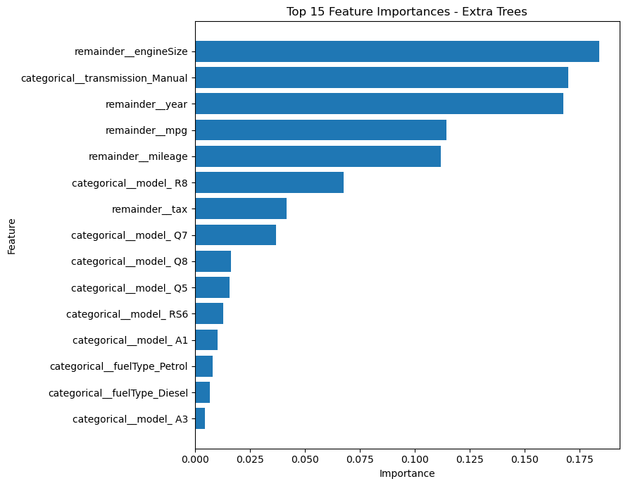

```python
top_features = feature_importance.head(15).sort_values("Importance")

plt.figure(figsize=(9,7))
plt.barh(top_features["Feature"], top_features["Importance"])

plt.xlabel("Importance")
plt.ylabel("Feature")
plt.title("Top 15 Feature Importances - Extra Trees")

plt.tight_layout()
plt.show()
```

## Final Model Evaluation

The models have now been trained and compared. The model with the best performance can be selected as the final model based on the evaluation results.

```python
best_row = model_comparison.loc[
    model_comparison["R2 Score"].idxmax()
]

print("Final Model:", best_row["Model"])
print("MAE:", best_row["MAE"])
print("R² Score:", best_row["R2 Score"])
```

```
Final Model: Extra Trees
MAE: 1574.4888132986275
R² Score: 0.9581252504123355
```

## Testing the Final Model

I will now use the selected model to make predictions on some test data and compare them with the actual prices.

```python
if best_model_name == "Linear Regression":
    final_model = linear_model
    final_predictions = y_pred_linear

elif best_model_name == "Random Forest":
    final_model = random_forest_model
    final_predictions = y_pred_rf

else:
    final_model = extra_trees_model
    final_predictions = y_pred_et
```

```python
final_predictions_table = pd.DataFrame({
    "Actual Price": y_test.values[:10],
    "Predicted Price": final_predictions[:10]
})

display(final_predictions_table)
```

|  | Actual Price | Predicted Price |
| --- | --- | --- |
| 0 | 12691 | 11400.000000 |
| 1 | 47816 | 54059.000000 |
| 2 | 21450 | 20585.275000 |
| 3 | 13849 | 14418.291667 |
| 4 | 12990 | 14160.283333 |
| 5 | 45490 | 44342.450000 |
| 6 | 34985 | 30860.000000 |
| 7 | 23990 | 27798.308333 |
| 8 | 14998 | 14058.808333 |
| 9 | 12360 | 13175.250000 |

## Final Model Performance

The final model was selected based on the highest R² score among the models tested.

A lower MAE means that the predicted prices are closer to the actual prices on average, while a higher R² score means that the model explains more of the variation in car prices.

```python
final_mae = mean_absolute_error(y_test, final_predictions)
final_r2 = r2_score(y_test, final_predictions)

print("Final Model:", best_model_name)
print("Final MAE:", final_mae)
print("Final R² Score:", final_r2)
```

```
Final Model: Extra Trees
Final MAE: 1574.4888132986275
Final R² Score: 0.9581252504123355
```

## Conclusion

In this project, I used the Audi used-car dataset to predict car prices.

I first explored the dataset, checked for missing values and duplicate records, and studied the relationship between car price and different features.

The categorical features were converted into numerical features using one-hot encoding. I then trained Linear Regression, Random Forest and Extra Trees regression models.

Among the three models, Extra Trees gave the highest R² score of about 0.958. Its MAE was about 1574, so it was selected as the final model.

Overall, the project shows that the available car features can be used to build a machine learning model for used car price prediction.

## Project Summary

Main steps followed in this project:

- Loaded and understood the Audi dataset
- Checked missing values and duplicate records
- Performed exploratory data analysis
- Separated features and target
- Encoded categorical features
- Split the data into training and testing sets
- Trained different regression models
- Evaluated the models using MAE and R²
- Compared the models
- Selected the best performing model

## Final Remarks

The models were compared using MAE and R² score, and the best performing model was selected based on the results.

Overall, the project shows how different car features can be used to build a machine learning model for used car price prediction.